# Lecture 3: Discrete Parametric Simulations

### Negative Binomial

Ok, so for most simulations, the preceding three distributions will probably cover 99.9% of applications where you’ve got a “coin flip” binary outcome. For the sake of completeness, we’ll also talk about the negative binomial.

The negative binomial is the distribution of the total number of trial required to acheive a specified umber of successes. I know w, that seems oddly specific right. Where would we ever need this? Well in a probability class the answer you’d probably get is that for sufficiently large samples the negative binomial can be ussed as a discrete approximation of a normal.

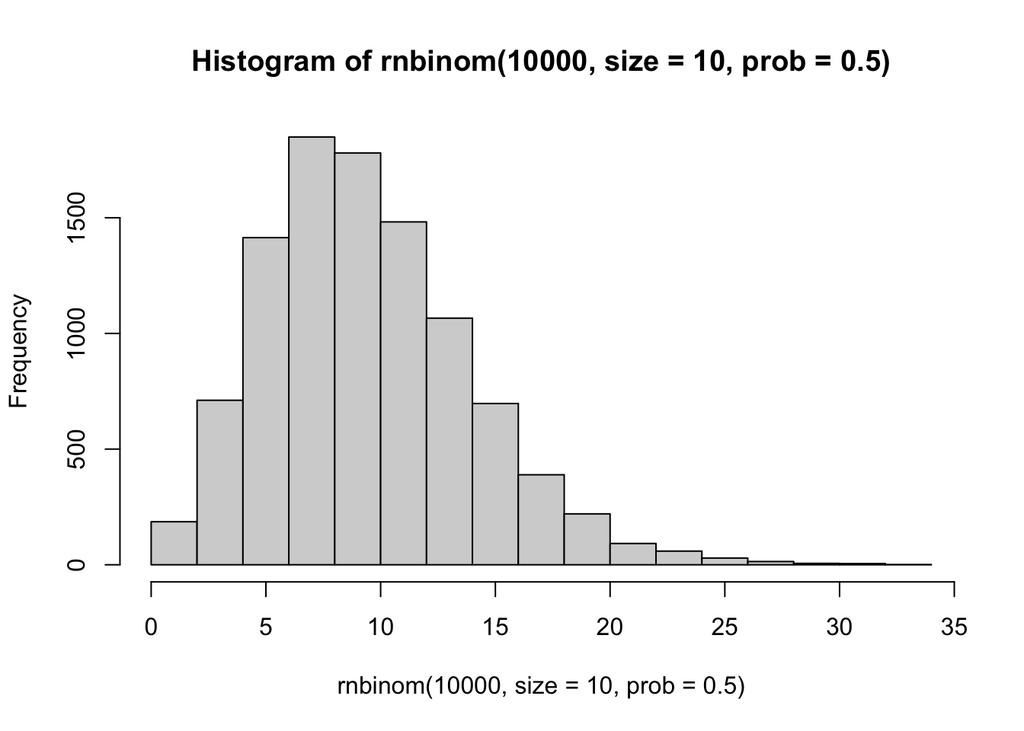

```r
hist(rnbinom(10000, size = 10, prob = 0.5))
```

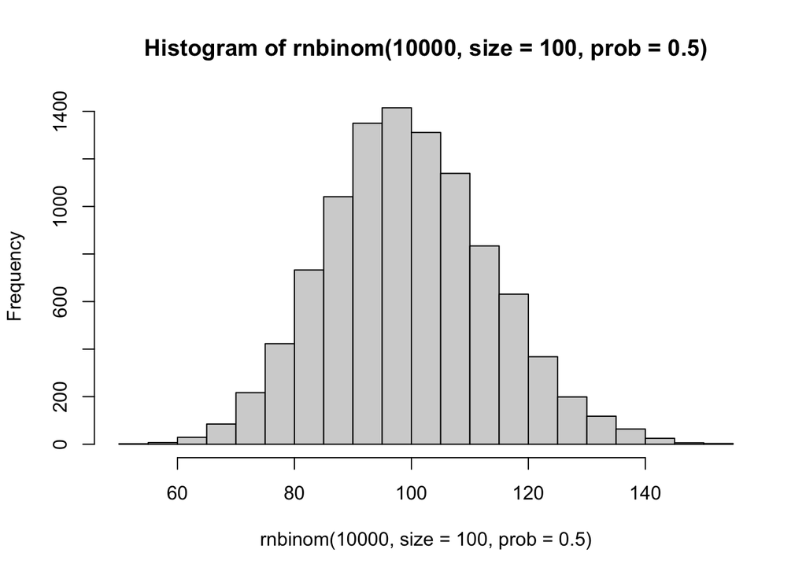

```r
hist(rnbinom(10000, size = 100, prob = 0.5))
```

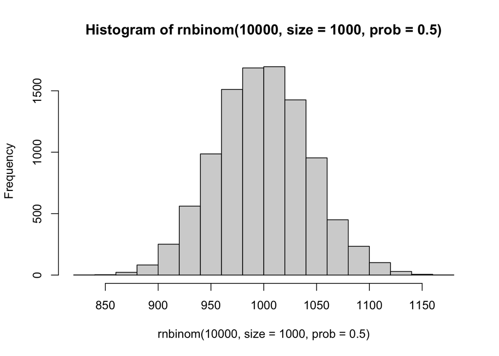

```r
hist(rnbinom(10000, size = 1000, prob = 0.5))
```

While that is a staitistically iteresting result, its seldom that useful. In practice, the negative binomial simply serves as the most flexible of the the discrete distributions for count data, with two parameters providing greater control of both the center of the distribution and the relative skew of the tail.

##Other Discrete Distributions

While you can clearly cover lots of ground statistically with a ‘coin flip’, not all discrete data is naturally modeled using a binary trial

###Poisson

The poisson is the original model for all “count” data - data that is discrete and greater than zero. The fun thing about this distribution is that it only has one parameter *lambda*, which is used to describe not only its center (expected value), but also its variance. So naturally, as the expected value of the count data becomes larger, so does the variability in the counts.

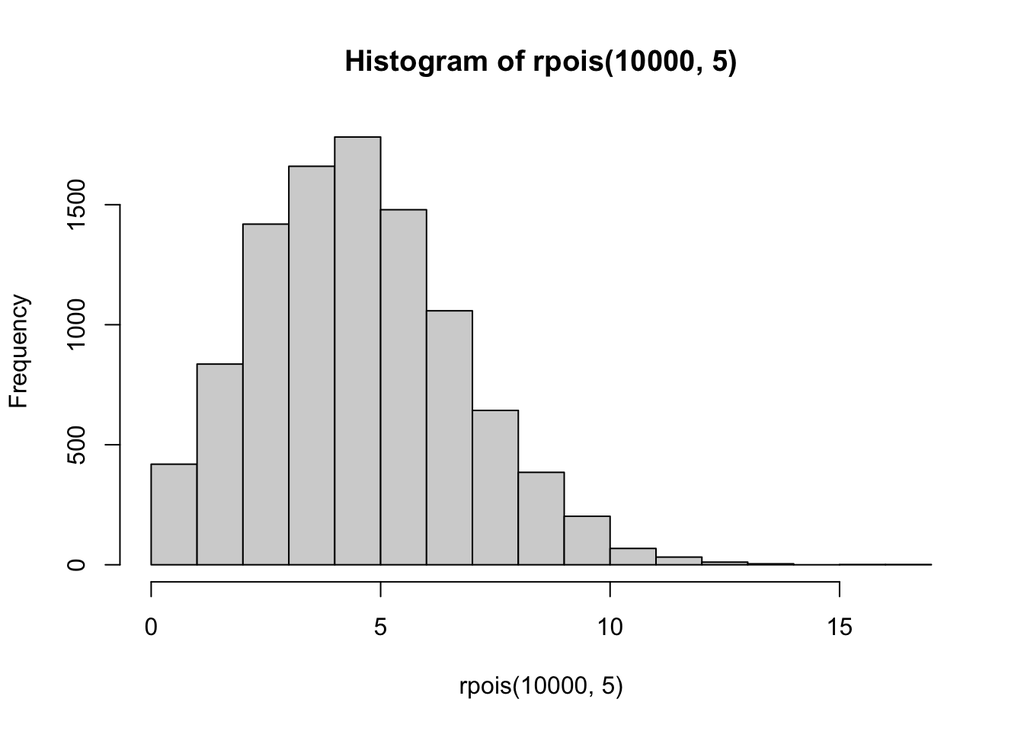

```r
hist(rpois(10000, 5))
```

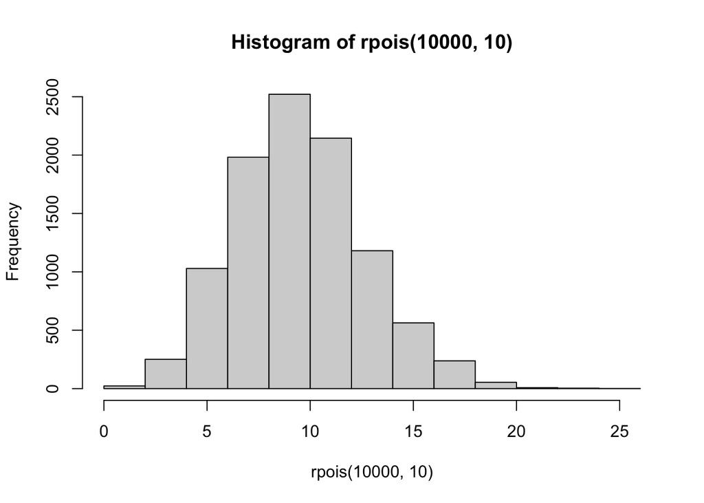

```r
hist(rpois(10000, 10))
```

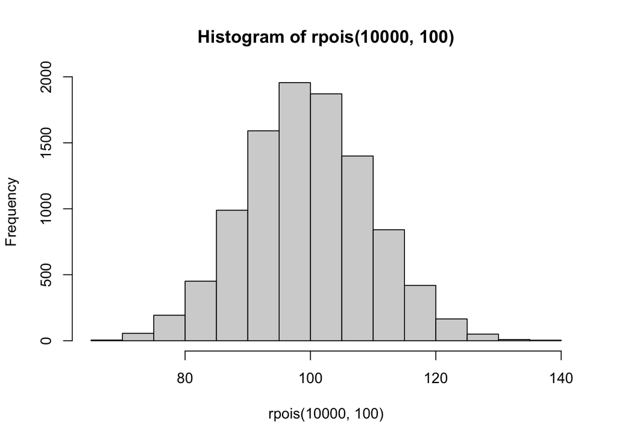

```r
hist(rpois(10000, 100))
```

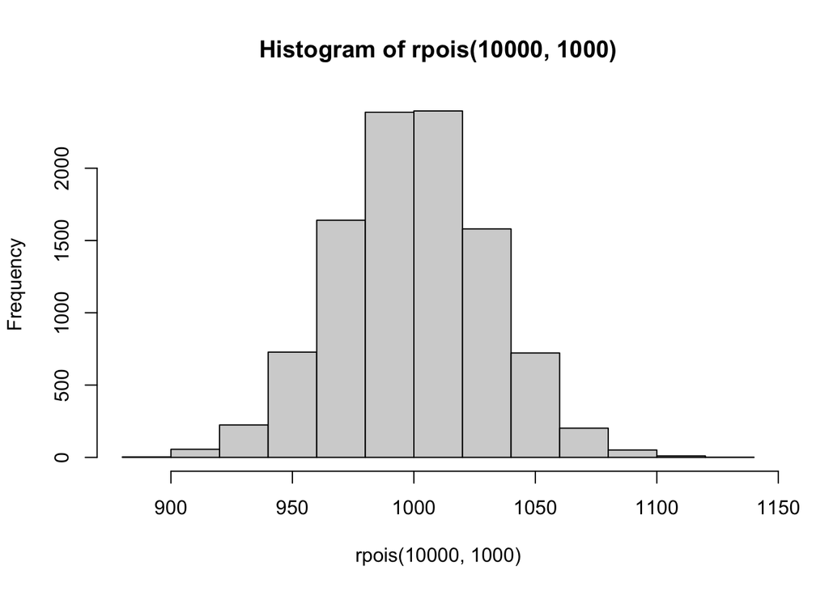

```r
hist(rpois(10000, 1000))
```

That is fairly intuitive - in most real world example variance scales with the relative magnitude of the metric. And if you are restricted to closed-form solutions to probabilistic problems, like the founders of statistics did pre-compupters, then having only one parameter is pretty handy. But in my experiance, most real world data has much thicker tails than a poisson will allow for (over-dispersion), and so I would argue that fitting a negative binomial will give you more freedom to more closely mimic real world data (assuming you have it).

###Multinomial

Alright, we finally get to my favorite discrete probability distribution - the mutinomial. Why is it my favorite? Because in dairy cows, we talk about time budgets a lot. A time budget is the relative amount of time that a cow dedicates to one of potentially several behaviors in a fixed amout of time. For example, amount of time spent lying, eating, ruminating, or walking in a given 24 hour management cycle. Sounding vaguely familiar from last weeks hw.

The multinomial distribution allows us generate a vector of random counts, where we specify first the total number of observations to randomly sample, and then the probability of an obsevation falling into each category (those probabilities summing to 1 across all categories).

This distribution isn’t just useful for time budgets. In the real world, you’ll find lots of categorical data may be normalilzed to a total count of some kind. Its particularly common any time time or space are major components of an applications, as such data are naturally constrained by strict domain constraints.

One thing to note, however, is that like a poison, this distribution can be a bit geometrically over-constrained relative to real world data. In particular, the variability asssumed at the edges of the distribution (really low or high probabilities) can be too low relative to the messiness of the real world - we’ll breifly touch on a stratedgy to deal with this next week.

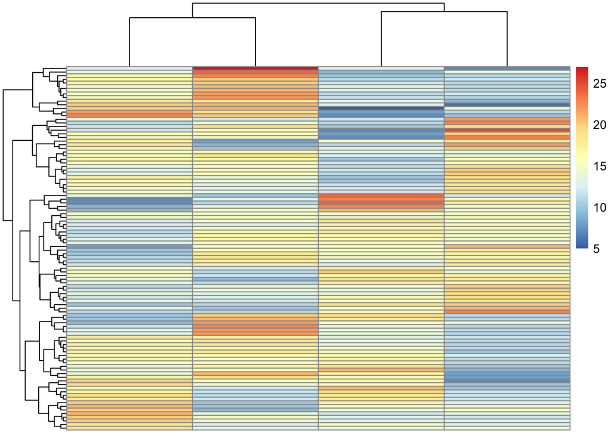

```r
# drawing from the center of the distribution -> high variance
temp <- rmultinom(100, 60, c(0.25, 0.25, 0.25, 0.25))
pheatmap(t(temp))
```

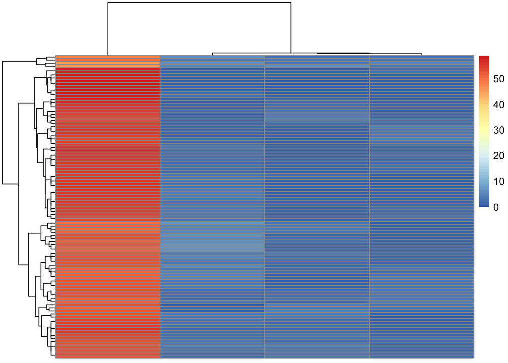

```r
# drawing the the edges of the distribution -> very little variance
temp <- rmultinom(100, 60, c(0.9, 0.05, 0.025, 0.025))
pheatmap(t(temp))
```

# In Class Exercise

Lets have a bit more fun with the coin flip distribution.

A random walk is a stochastic process where at each step the direction and distance you move in a space is dictated by some probability distirbution. But because where you are goig depends partly on where you’ve been, the probability theory gets pretty weird pretty fast.

A bernoulli coin flip is actually the basis for the simplest biary random walk, where at each step you either move “forward” (+1) or backwards (-1) along a one directional line.

Simulate 500 of these random walks of 10,000 coin flips. For each random walk, what step is your walk fartherst away from the origin? Plot a histogram of these max step positions. Notice anything interesting/weird? (Note: the cumsum function will help a lot here). Take a guess at why might the distributions be acting this way?

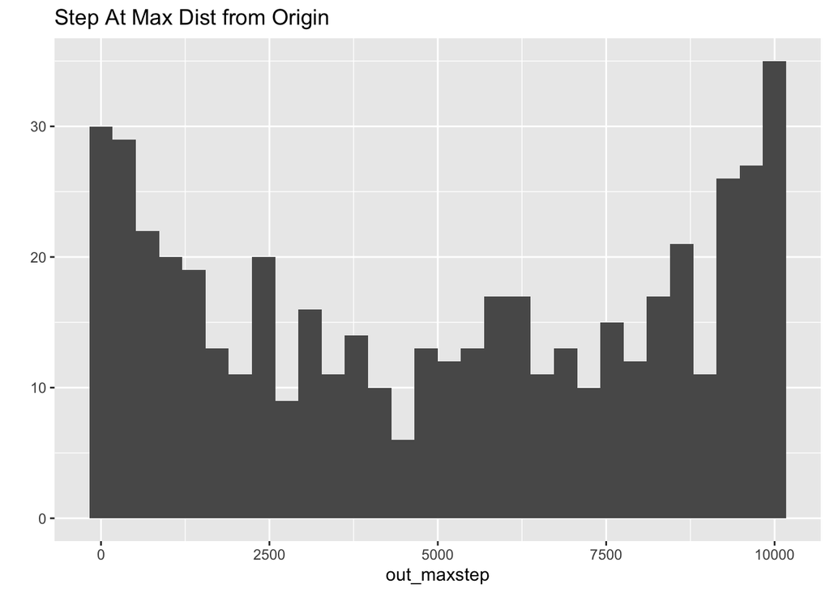

```r
set.seed(61916)

out_max <- rep(NA,500)
out_maxstep <- rep(NA,500)
out_steps <- array()

for(i in 1:500){

  temp  <- cumsum(ifelse(rbernoulli(10000, p = 0.5),-1,1))

  #out_maxstep[i] <- max(abs(temp))
  out_maxstep[i] <- which.max(temp)

}

#qplot(out_max, main = 'Max Dist from Origin')
qplot(out_maxstep, main = 'Step At Max Dist from Origin')
```

# HW

## Part 1

Using the code we wrote in the first class to simulate the lady tasting tea, how can we draw from the bernoulli distribution to mimic this process? Rerun your simulation use random draws from a beroulli distribution. Did we get the same result as before?

## Part 2

How could we use a bionomial distribution to mimic the lady tasting tea to streamline and simplify this simulation. Breifly explain your reasoning/assumptions, and write a simplified simulation. Are the results the same as before?